# Assignment_1

Rohit Koonireddy

2023-10-23

## Answer to Question 1

### Q1.A)

```r
setwd("D:/Sem_4/Applied Econometrics in Environmental and Energy Policy/HomeWork/TH1/")
#list.files(getwd())
load("Takehome_1.RData")
object_names <- ls()
object_names
```

```
## [1] "Takehome_1"
```

```r
class(Takehome_1)
```

```
## [1] "data.frame"
```

```r
str(Takehome_1)
```

```
## 'data.frame':    2064 obs. of  31 variables:
##  $ id              : int  42 42 42 42 42 42 42 42 42 42 ...
##  $ state           : chr  "Alabama" "Alabama" "Alabama" "Alabama" ...
##  $ label           : chr  "AL" "AL" "AL" "AL" ...
##  $ fips            : num  1 1 1 1 1 1 1 1 1 1 ...
##  $ region          : chr  "E S Cen" "E S Cen" "E S Cen" "E S Cen" ...
##  $ year            : num  1966 1967 1968 1969 1970 ...
##  $ apop_adj        : int  2136436 2167342 2168248 2188154 2209993 2261320 2305479 2353078 2406584 2464249 ...
##  $ cpi87           : num  28.5 29.4 30.6 32.3 34.2 ...
##  $ fsize           : num  3.66 3.83 4.41 4.32 4.27 ...
##  $ fgastax         : num  4 4 4 4 4 4 4 4 4 4 ...
##  $ hug             : num  1246736 1296855 1366642 1436548 1527691 ...
##  $ lic_driver      : num  1554168 1598288 1613522 1686942 1740279 ...
##  $ no_auto         : int  1405048 1397923 1445865 1470975 1559097 1656566 1746518 1828875 1854168 1900295 ...
##  $ no_truck        : int  319476 329713 352187 378680 399028 428556 472882 516794 547374 584074 ...
```

[output cut: 17 more lines]

```r
require(plm) # For panel data analysis
require(lfe) # For fixed effects models

#create the required panel data
data_df <- pdata.frame(Takehome_1, index = c("state","year"))
head(data_df)
```

```
##              id   state label fips  region year apop_adj cpi87 fsize fgastax
## Alabama-1966 42 Alabama    AL    1 E S Cen 1966  2136436  28.5  3.66       4
## Alabama-1967 42 Alabama    AL    1 E S Cen 1967  2167342  29.4  3.83       4
## Alabama-1968 42 Alabama    AL    1 E S Cen 1968  2168248  30.6  4.41       4
## Alabama-1969 42 Alabama    AL    1 E S Cen 1969  2188154  32.3  4.32       4
## Alabama-1970 42 Alabama    AL    1 E S Cen 1970  2209993  34.2  4.27       4
## Alabama-1971 42 Alabama    AL    1 E S Cen 1971  2261320  35.7  4.55       4
##                  hug lic_driver no_auto no_truck gsp_capita realincome_state
## Alabama-1966 1246736    1554168 1405048   319476       2.56         26356898
## Alabama-1967 1296855    1598288 1397923   329713       2.71         26981816
## Alabama-1968 1366642    1613522 1445865   352187       2.98         28331660
## Alabama-1969 1436548    1686942 1470975   378680       3.23         29117201
## Alabama-1970 1527691    1740279 1559097   399028       3.50         29879675
## Alabama-1971 1627315    1800717 1656566   428556       3.79         31407134
##              taxin_gas_price road_mileage railpop sgastax pop_state_adj
## Alabama-1966            32.5        76765       0       7       3458841
## Alabama-1967            33.0        77850       0       7       3451981
## Alabama-1968            33.8        78097       0       7       3439122
## Alabama-1969            33.5        78080       0       7       3432262
## Alabama-1970            35.3        78872       0       7       3449846
## Alabama-1971            35.7        79036       0       7       3495882
##              urbanization vmt_state drivers_capita autos_capita state_num
## Alabama-1966        0.682     14890          0.727        0.658         1
## Alabama-1967        0.683     15950          0.737        0.645         1
## Alabama-1968        0.683     16530          0.744        0.667         1
## Alabama-1969        0.684     17030          0.771        0.672         1
## Alabama-1970        0.690     19754          0.787        0.705         1
## Alabama-1971        0.691     21164          0.796        0.733         1
##              gas_tax_all trend trend2 trend3 trend4
## Alabama-1966          11     0      0      0      0
## Alabama-1967          11     1      1      1      1
## Alabama-1968          11     2      4      8     16
## Alabama-1969          11     3      9     27     81
## Alabama-1970          11     4     16     64    256
## Alabama-1971          11     5     25    125    625
```

Recreating the regressions for Table 1 :

```r
#Function to calculate percentage changes
get_delta_consumption_price <- function(model_inside, percentage_change){
  coef_values <- coef(model_inside)
  standard_errors <- summary(model_inside)$coefficients[, "Std. Error"]

  actual_coefficients <- exp(coef_values)
  actual_standard_errors <- actual_coefficients * standard_errors

  # Calculate the percent change in gas consumption
  percent_change_1 <- coef_values * percentage_change * 100 + standard_errors

  # Calculate the standard error of the percent change
  se_percent_change_1 <- standard_errors * percentage_change * 100

 return(paste0("percentage change: ", format(percent_change_1, nsmall = 2), "\n", "standard error percentage change: ", format(se_percent_change_1, nsmall = 2)))

}


#Model 1
# 1. Fixed Effects (within) <- effect uses the state fixed effects
model_1 <- plm(log(hug/apop_adj) ~ log(taxin_gas_price), data = data_df, model = "within", effect = "individual")


# Model 2
# 2. Fixed Effects (within) <- effect uses the state fixed effects
#create variables
data_df$tax.exlc.price <- data_df$taxin_gas_price - (data_df$gas_tax_all)
data_df$tax_ratio <- data_df$gas_tax_all / data_df$taxin_gas_price
model_2 <- plm(log(hug/apop_adj) ~ log(tax.exlc.price)+log(1+tax_ratio), data = data_df, model = "within", effect = "individual")


#Model 3 <- uses both state and year fixed effects
model_3 <- plm(log(hug/apop_adj) ~ log(taxin_gas_price), data = data_df, model = "within", effect = "twoways")

#Model 4 <-
model_4 <- plm(log(hug/apop_adj) ~ log(tax.exlc.price)+log(1+tax_ratio), data = data_df, model = "within", effect = "twoways")
```

The results are not similar to what we see in the paper but close for Regression 1. Now we see parts 5,6,7,8

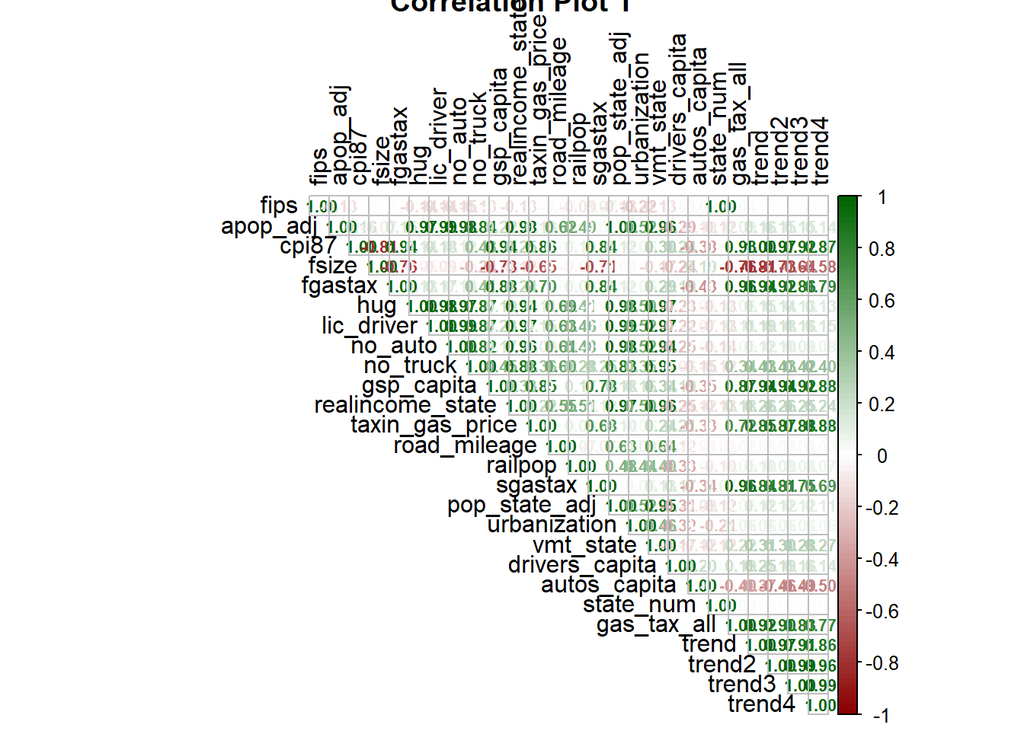

```r
data_df_numeric <- data_df[,!colnames(data_df) %in% c("state","label","region","year","id","sgastax","fgastax")]
data_df_numeric <- Takehome_1[,!colnames(Takehome_1) %in% c("state","label","region","year","id")]

# understand variable correlation
correlation_matrix_1 <- cor(data_df_numeric)
# First Correlation Plot
require(corrplot)
corrplot(correlation_matrix_1, method = "number", use = "complete",
         tl.col = "black", type = "upper", tl.srt = 90,
         diag = TRUE, sig.level = 0.05, insig = "blank",
         addCoef.col = "black", number.cex = 0.7,
         main = "Correlation Plot 1",
         col = colorRampPalette(c("darkred", "white", "darkgreen"))(100),
         lim = c(-1, 1))
```

Based on the correlation matrix, following fields can be used as covariates (I ignore the items that have very high correlation): 1. state_num Identifier for the state FIPS code 2. trend 3. no_truck 4. road_mileage 5. fsize 6. urbanization 7. drivers_capita 8. autos_capita

```r
#Model 5 <- uses covariates along with both fixed affects
model_5 <- plm(log(hug/apop_adj) ~ log(taxin_gas_price)+tax_ratio+state_num+trend+no_truck+road_mileage+fsize+urbanization+drivers_capita+autos_capita, data = data_df, model = "within", effect = "twoways")

#Model 6
model_6 <- plm(log(hug/apop_adj) ~ log(tax.exlc.price)+log(1+tax_ratio)+state_num+trend+no_truck+road_mileage+fsize+urbanization+autos_capita, data = data_df, model = "within", effect = "twoways")

#Model 7
model_7 <- plm(log(hug/apop_adj) ~ log(taxin_gas_price)+state_num+trend+trend2+no_truck+road_mileage+fsize+urbanization+drivers_capita+autos_capita, data = data_df, model = "within", effect = "twoways")

#Model 8
model_8 <- plm(log(hug/apop_adj) ~ log(tax.exlc.price)+log(1+tax_ratio)+state_num+trend+trend2+no_truck+road_mileage+fsize+urbanization+autos_capita, data = data_df, model = "within", effect = "twoways")

model_list_1 <- list(model_1, model_2, model_3, model_4)
model_list_2 <- list(model_5,model_6,model_7,model_8)

stargazer(model_list_1, type= "text")
```

```
##
## ===========================================================================================================================
##                                                               Dependent variable:
##                      ------------------------------------------------------------------------------------------------------
##                                                                log(hug/apop_adj)
##                                 (1)                       (2)                      (3)                       (4)
## ---------------------------------------------------------------------------------------------------------------------------
## log(taxin_gas_price)         -0.060***                                          -0.192***
##                               (0.003)                                            (0.029)
##
## log(tax.exlc.price)                                    -0.078***                                          -0.233***
##                                                         (0.003)                                            (0.028)
##
## log(1 + tax_ratio)                                     -0.524***                                          -1.470***
##                                                         (0.032)                                            (0.093)
##
## ---------------------------------------------------------------------------------------------------------------------------
## Observations                   2,064                     2,064                    2,064                     2,064
## R2                             0.184                     0.250                    0.022                     0.113
## Adjusted R2                    0.164                     0.232                    -0.023                    0.073
## F Statistic          454.000*** (df = 1; 2015) 335.000*** (df = 2; 2014) 44.400*** (df = 1; 1973) 126.000*** (df = 2; 1972)
## ===========================================================================================================================
## Note:                                                                                           *p<0.1; **p<0.05; ***p<0.01
```

```r
stargazer(model_list_2, type= "text")
```

```
##
## ============================================================================================================================
##                                                                Dependent variable:
##                      -------------------------------------------------------------------------------------------------------
##                                                                 log(hug/apop_adj)
##                                 (1)                       (2)                       (3)                       (4)
## ----------------------------------------------------------------------------------------------------------------------------
## log(taxin_gas_price)         -0.164***                                           -0.146***
##                               (0.024)                                             (0.025)
##
## tax_ratio                    -0.631***
##                               (0.054)
##
## log(tax.exlc.price)                                    -0.203***                                           -0.203***
##                                                         (0.025)                                             (0.025)
##
## log(1 + tax_ratio)                                     -1.280***                                           -1.280***
##                                                         (0.084)                                             (0.084)
##
## no_truck                      -0.000*                  -0.000***                  -0.000                   -0.000***
##                               (0.000)                   (0.000)                   (0.000)                   (0.000)
##
## road_mileage                0.00000***                0.00000***                0.00000***                0.00000***
##                              (0.00000)                 (0.00000)                 (0.00000)                 (0.00000)
##
## fsize                        -0.022***                 -0.020**                  -0.019**                  -0.020**
##                               (0.008)                   (0.008)                   (0.008)                   (0.008)
##
## urbanization                 -0.137**                  -0.242***                 -0.133**                  -0.242***
##                               (0.062)                   (0.064)                   (0.064)                   (0.064)
##
## drivers_capita               0.248***                                            0.277***
##                               (0.020)                                             (0.021)
##
## autos_capita                 0.302***                  0.337***                  0.314***                  0.337***
##                               (0.017)                   (0.017)                   (0.018)                   (0.017)
##
## ----------------------------------------------------------------------------------------------------------------------------
## Observations                   2,064                     2,064                     2,064                     2,064
## R2                             0.335                     0.291                     0.288                     0.291
## Adjusted R2                    0.302                     0.256                     0.253                     0.256
## F Statistic          124.000*** (df = 8; 1966) 115.000*** (df = 7; 1967) 114.000*** (df = 7; 1967) 115.000*** (df = 7; 1967)
## ============================================================================================================================
## Note:                                                                                            *p<0.1; **p<0.05; ***p<0.01
```

```r
#you can run for each model to see the output for percentage using this code.
#get_delta_consumption(model_1,0.05)
```

Overall, my results are not exactly same as those present in the paper but they are close. I am not entirely sure if the covariates and transformed covariates I used are the same as the ones authors used.

### Q1.B)

a)Coefficient of fuel tax vary more i.e. the negative change in the log(fuel consumption) in more than the affect of the tax.exclusive fuel price. b) For the regressions I ran, it is evident that, tax ratio significant under-miner for fuel consumption.

## Answer to Question 2

### Q2.A)

State fixed effects and state quadratic trends are both used in panel data analysis to control for state-specific factors that may affect the dependent variable (gasoline consumption in this case). The key differences between them are as follows:

State Fixed Effects: State fixed effects capture the average difference in the dependent variable for each state compared to a reference state (usually the omitted category). They control for all time-invariant state-specific factors that could affect the dependent variable. For example, they account for factors such as state-level policies, culture, and geography. In the context of this paper, state fixed effects would capture the unchanging differences in gasoline consumption among states over time.

State Quadratic Trends: State quadratic trends capture the long-term trend or curvature in the relationship between the state-specific variable and the dependent variable. They allow for a non-linear, time-varying relationship between the state-specific variable and the dependent variable. For example, if a state’s gasoline consumption follows a quadratic trend over time due to changes in population, economic development, or other factors, state quadratic trends would capture this pattern.

### Q2.B)

The decline in the absolute value of the main coefficients when state quadratic trends are included suggests that the initial results in columns (5) and (6) might have overestimated the effect of gasoline taxes (in absolute terms). This could be due to the omission of the long-term trends and curvatures in the relationship between gasoline taxes and consumption that are captured by the state quadratic trends. In other words, the inclusion of state quadratic trends provides a more refined and accurate estimate of the effect of gasoline taxes by accounting for these trends.

### Q2.C)

Controlling for state-specific shocks can be challenging in panel data analysis. While state fixed effects account for time-invariant state-specific factors, they do not directly capture state-specific shocks that may vary from year to year. To control for such shocks, we often rely on time-specific fixed effects, year fixed effects, or additional covariates that might indirectly capture state-specific variations. However, including time-specific fixed effects or year fixed effects may not fully control for state-specific shocks. Alternatively, we can include lagged values of the dependent variable or other lagged covariates to account for serial correlation and potential state-specific shocks. The choice of approach depends on the specific data and research question.

## Answer to Question 3

One potential problem with the set of estimations presented in Table 2, given that it’s a demand model, is endogeneity. Endogeneity occurs when one or more independent variables are correlated with the error term in a regression model. In the context of this study, endogeneity could arise for several reasons:

Reverse Causality: The direction of causality between gasoline taxes and gasoline consumption might not be one-way. Consumers’ behavior could influence changes in gasoline taxes, which would lead to reverse causality. For example, if policymakers respond to changes in consumer demand for gasoline by adjusting taxes, this creates a feedback loop.

Omitted Variables: The estimations in Table 2 include a variety of fixed effects and covariates to control for potential confounding factors. However, there might still be unobserved variables that affect both gasoline taxes and consumption. Omitted variables can lead to endogeneity if these unobserved factors are correlated with the included independent variables.

Measurement Error: Measurement error in the gasoline tax variable or other variables used in the model could introduce endogeneity. Measurement errors can bias the coefficient estimates and lead to incorrect inferences.

Simultaneity Bias: If there are feedback effects between gasoline consumption and gasoline taxes that occur simultaneously, this could result in simultaneity bias. In a demand model, this would manifest as a two-way relationship between prices (gasoline taxes) and quantities (consumption).

Non-Linear Relationships: The model specifications in Table 2 assume a linear relationship between the independent variables and gasoline consumption. If the actual relationship is non-linear, it can lead to endogeneity issues.

Dynamic Effects: The study may not account for lagged effects and dynamic adjustments in consumers’ responses to gasoline taxes. Ignoring dynamic effects can result in endogeneity, especially if consumers respond to past changes in taxes.

The presence of endogeneity can bias the coefficient estimates and standard errors, leading to invalid results. It can also make it challenging to establish causal relationships between gasoline taxes and consumption. To address potential endogeneity issues, researchers often employ instrumental variable (IV) approaches, natural experiments, or other advanced econometric techniques. Additionally, the use of panel data with fixed effects is one way to control for unobserved heterogeneity and address endogeneity concerns.

## Answer to Question 4

It is evident from the study that the increased perception of more taxes on gasoline have positive affects on environment and revenue. While it is beneficial for governments to incorporate higher taxes, generalized view could also imply adversely affective economically backward sectors of the society. It could be beneficial to do more study and incorporate taxes based on state level tolerance. Wealthier states or urban areas can pay higher taxes which can both benefit in efficient usage of the infrastructure.

- Understanding Elasticity: The study highlights the importance of knowing how consumers react to tax changes. This helps policymakers design effective tax policies.
- Tax Goals: Decide if the goal of gasoline taxes is to reduce consumption, raise revenue, or both. The study shows that consumers respond more to tax changes than price changes.
- Effective Tool: Gasoline taxes are effective for reducing consumption and promoting energy efficiency.
- Optimal Tax Levels: Carefully assess and model the ideal tax levels to balance goals.
- Monitoring: Implement a robust monitoring system to evaluate tax policy effects.
- Public Support: Engage the public to explain the need for gasoline taxes.
- Income Distribution: Consider how taxes affect different income groups and use subsidies if needed.
- Long-Term View: Think long-term and review policies periodically.
- Global Commitments: Align tax policies with international environmental goals.
- Research: Keep researching and collecting data to refine policies.